# Stellar Classification with Machine Learning and Statistical Analysis

Gabriella Weis

#### Introduction:

Predictive models and statistical tests are beneficial for understanding stellar evolution and doing astrophysical research. By finding correlations between star characteristics and types, it can make it easier for scientists to gain insight into stellar life cycles, identify relationships between different stars and their environments, and classify large amounts of stars quickly instead of slowly and manually. This is especially important because of the extensive amounts of stellar data, much of which is difficult to handle without access to high-scale computational abilities.

I am using a kaggle dataset of 240 star observations to conduct my statistical tests and create my models. According to the authors, the dataset is meant to prove that stars follow the Hertzsprung-Russell Diagram (HR-Diagram) so that we can classify stars by plotting its features based on the model.

Here is the link to the data: https://www.kaggle.com/datasets/deepu1109/star-dataset/data

#### First, load in the data and name the variables accordingly for ease of use.

```r
library(readr)
stars <- read.csv("C:/Users/glwei/OneDrive/Documents/CC Final Project/6 class csv.csv")
names(stars) <- c("Temperature (K)", "Luminosity(L/Lo)", "Radius(R/Ro)", "Absolute magnitude(Mv)", "Star type", "Star color", "Spectral Class")
View(stars)
```

#### Load in tidyverse.

```r
library(tidyverse)
```

#### Calculate general summary stats.

```r
summary(stars$`Temperature (K)`)
```

```
##    Min. 1st Qu.  Median    Mean 3rd Qu.    Max.
##    1939    3344    5776   10497   15056   40000
```

```r
summary(stars$`Luminosity(L/Lo)`)
```

```
##     Min.  1st Qu.   Median     Mean  3rd Qu.     Max.
##      0.0      0.0      0.1 107188.4 198050.0 849420.0
```

```r
summary(stars$`Radius(R/Ro)`)
```

```
##      Min.   1st Qu.    Median      Mean   3rd Qu.      Max.
##    0.0084    0.1027    0.7625  237.1578   42.7500 1948.5000
```

```r
summary(stars$`Absolute magnitude(Mv)`)
```

```
##    Min. 1st Qu.  Median    Mean 3rd Qu.    Max.
## -11.920  -6.232   8.313   4.382  13.697  20.060
```

#### Let’s make some plots!

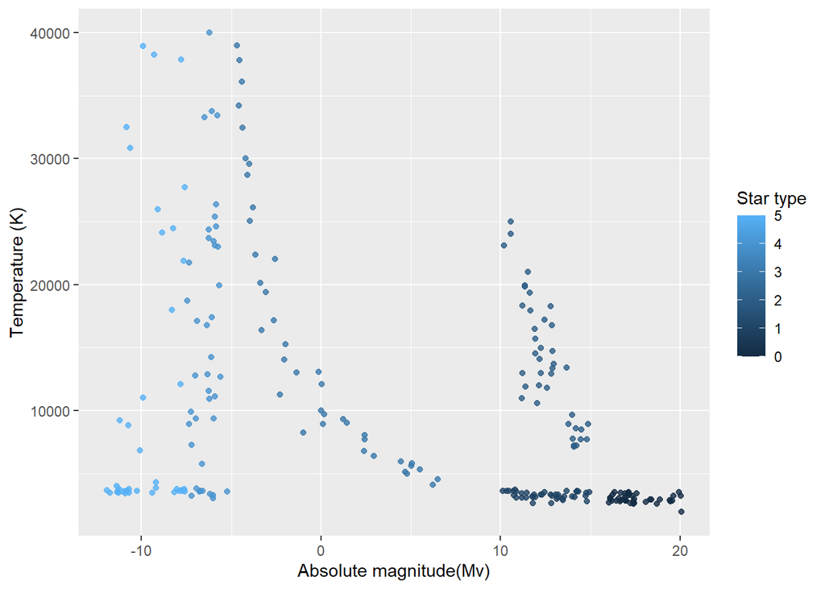

```r
# absolute magnitude vs. temperature over star type scatterplot
ggplot(stars, aes(x = `Absolute magnitude(Mv)`, y = `Temperature (K)`, color = `Star type`)) +
  geom_point(alpha = 0.8)
```

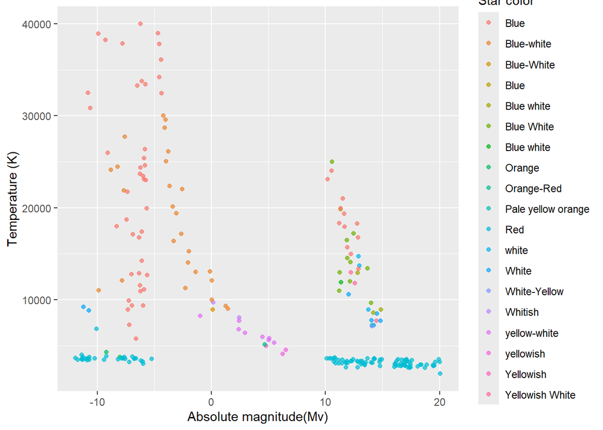

```r
# absolute magnitude vs. temperature over star color scatterplot
ggplot(stars, aes(x = `Absolute magnitude(Mv)`, y = `Temperature (K)`, color = `Star color`)) +
  geom_point(alpha = 0.7)
```

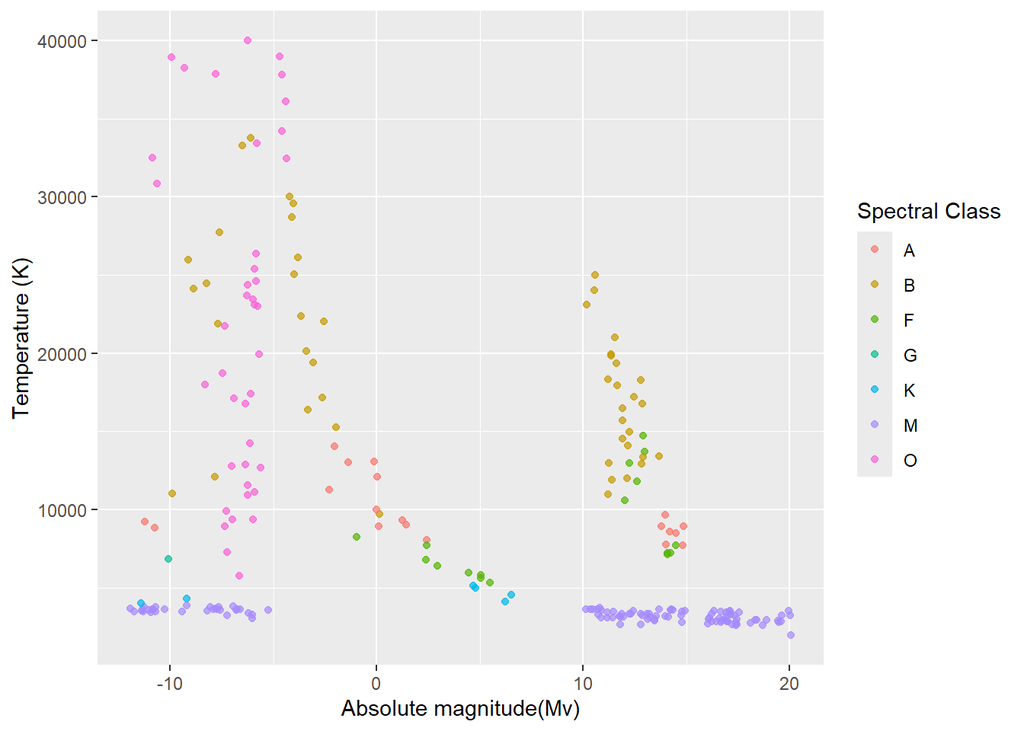

```r
# absolute magnitude vs. temperature over spectral class scatterplot
ggplot(stars, aes(x = `Absolute magnitude(Mv)`, y = `Temperature (K)`, color = `Spectral Class`)) +
  geom_point(alpha = 0.7)
```

These plots look an awful lot like the Hertzsprung-Russell Diagram (HR-Diagram)…

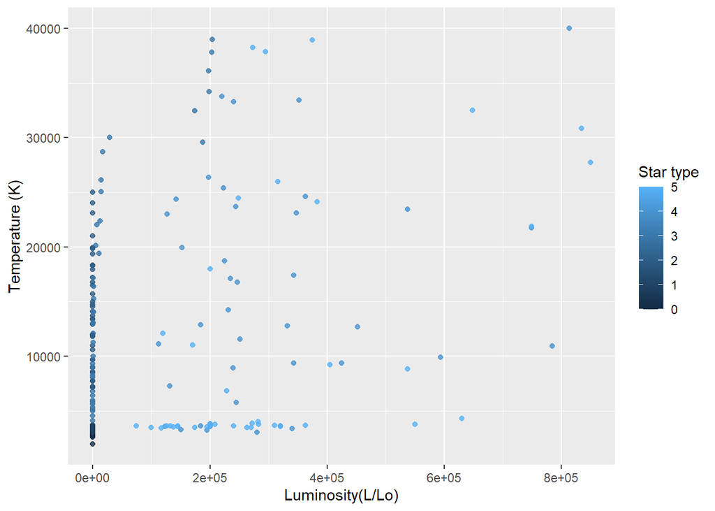

```r
# luminosity vs. temperature over star type scatterplot
ggplot(stars, aes(x = `Luminosity(L/Lo)`, y = `Temperature (K)`, color = `Star type`)) +
  geom_point(alpha = 0.8)
```

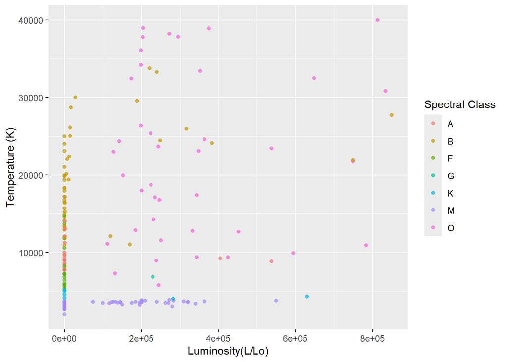

```r
# luminosity vs. temperature over spectral class scatterplot
ggplot(stars, aes(x = `Luminosity(L/Lo)`, y = `Temperature (K)`, color = `Spectral Class`)) +
  geom_point(alpha = 0.7)
```

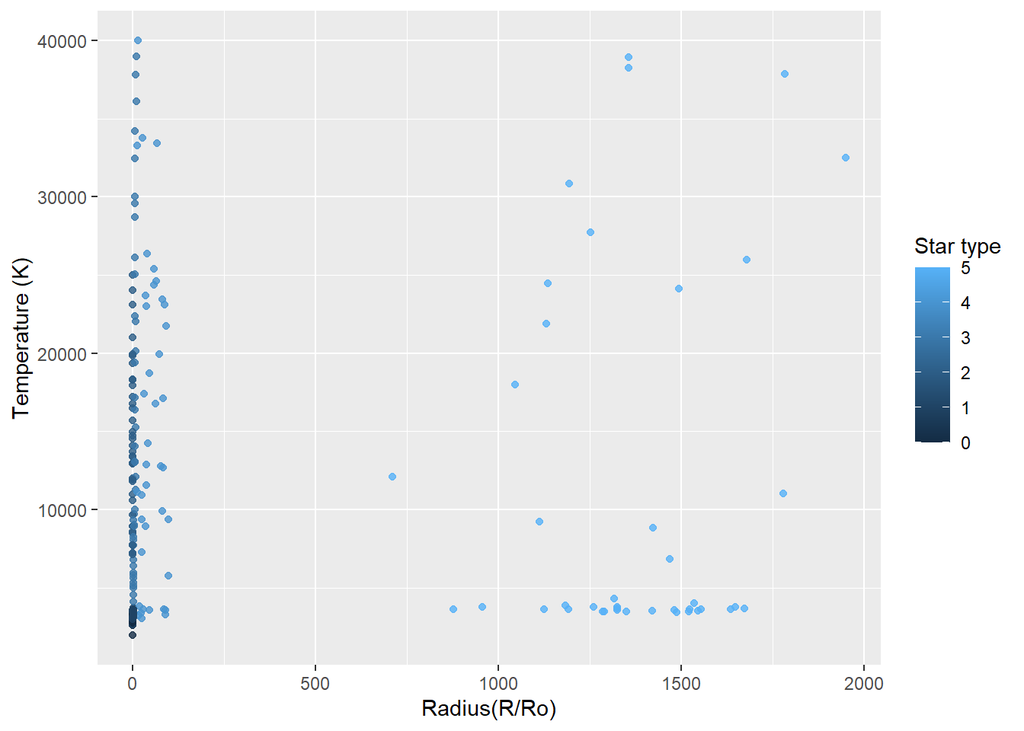

```r
# radius vs. temperature over star type scatterplot
ggplot(stars, aes(x = `Radius(R/Ro)`, y = `Temperature (K)`, color = `Star type`)) +
  geom_point(alpha = 0.8)
```

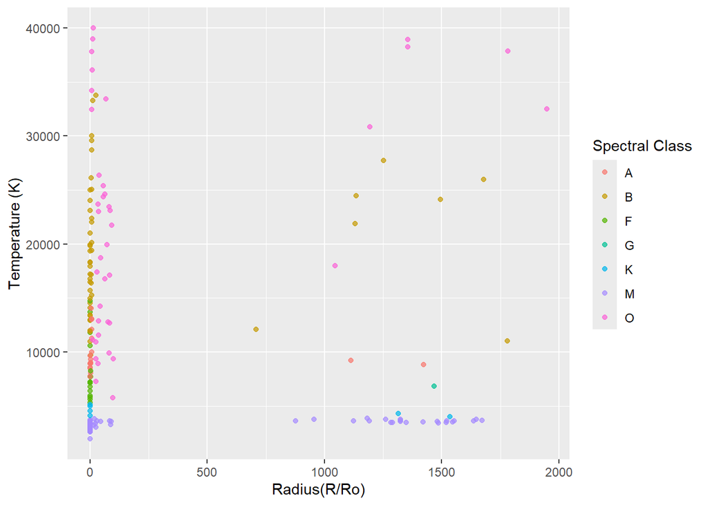

```r
# radius vs. temperature over spectral class scatterplot
ggplot(stars, aes(x = `Radius(R/Ro)`, y = `Temperature (K)`, color = `Spectral Class`)) +
  geom_point(alpha = 0.7)
```

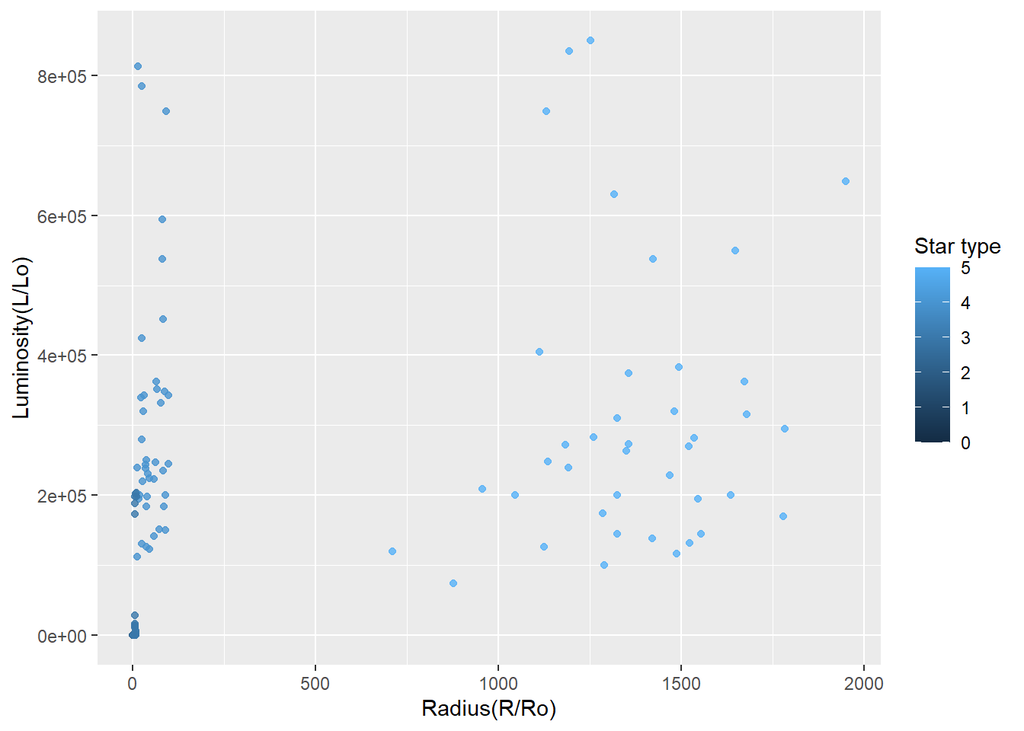

```r
# radius vs. luminosity over star type scatterplot
ggplot(stars, aes(x = `Radius(R/Ro)`, y = `Luminosity(L/Lo)`, color = `Star type`)) +
  geom_point(alpha = 0.8)
```

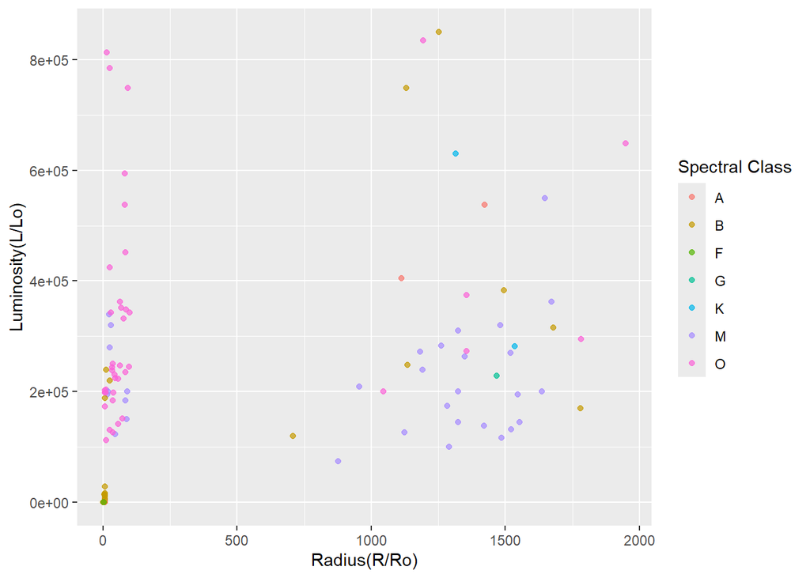

```r
# radius vs. luminosity over spectral class scatterplot
ggplot(stars, aes(x = `Radius(R/Ro)`, y = `Luminosity(L/Lo)`, color = `Spectral Class`)) +
  geom_point(alpha = 0.7)
```

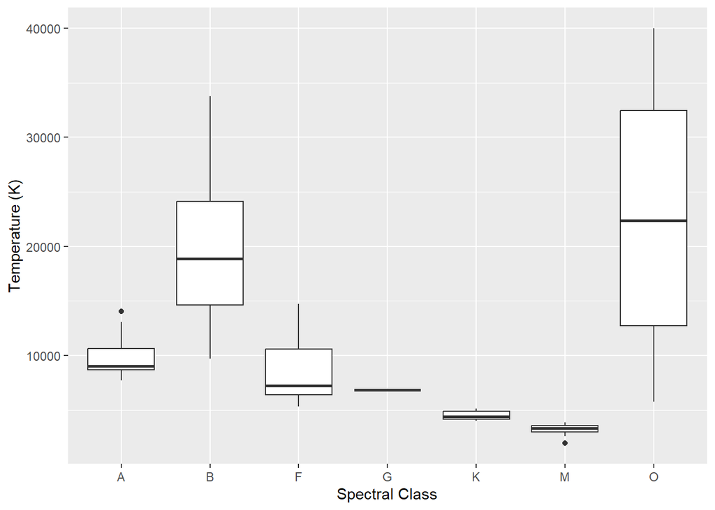

```r
# boxplot of temperature across spectral class
ggplot(stars, aes(x = `Spectral Class`, y = `Temperature (K)`)) +
  geom_boxplot()
```

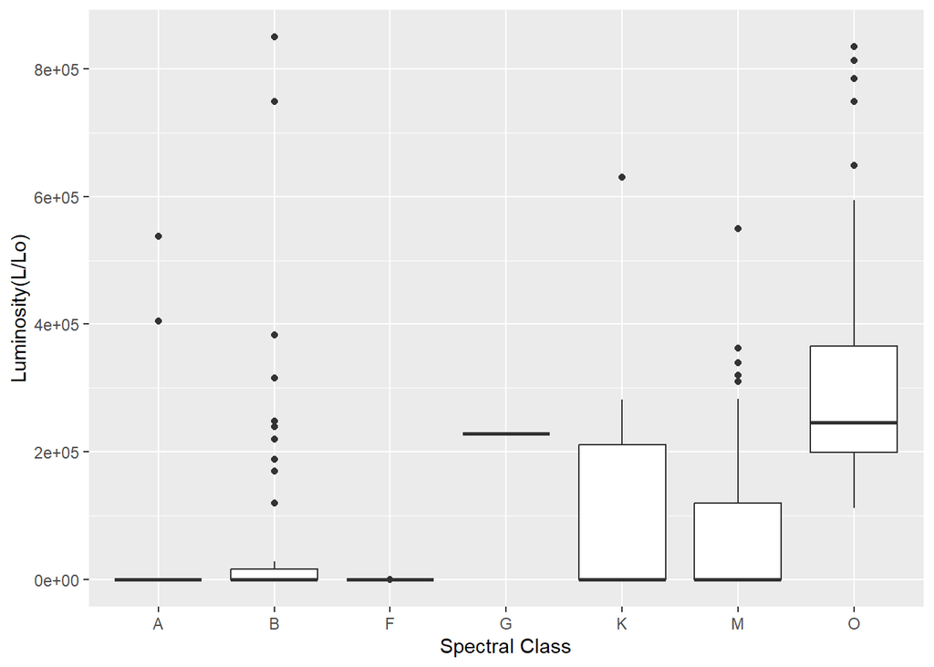

```r
# boxplot of luminosity across spectral class
ggplot(stars, aes(x = `Spectral Class`, y = `Luminosity(L/Lo)`)) +
  geom_boxplot()
```

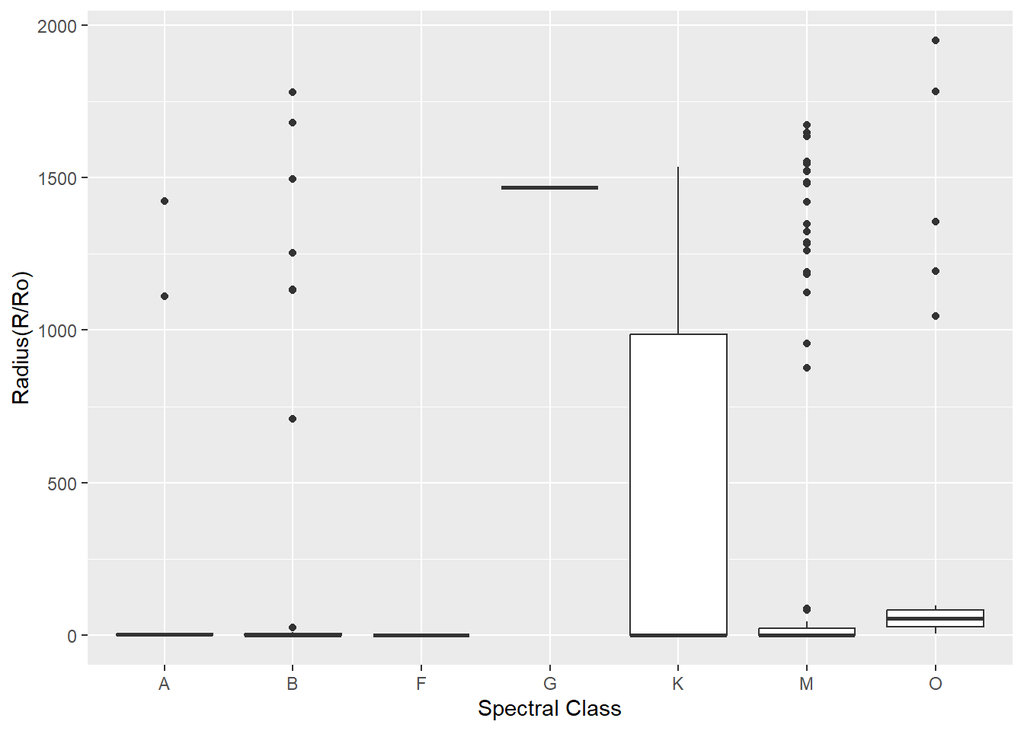

```r
# boxplot of radius across spectral class
ggplot(stars, aes(x = `Spectral Class`, y = `Radius(R/Ro)`)) +
  geom_boxplot()
```

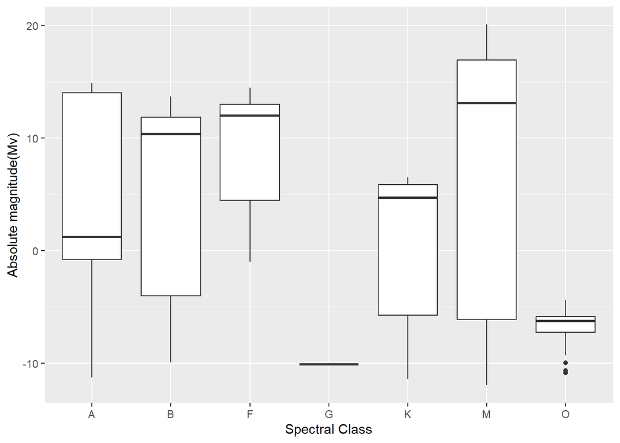

```r
# boxplot of absolute magnitude across spectral class
ggplot(stars, aes(x = `Spectral Class`, y = `Absolute magnitude(Mv)`)) +
  geom_boxplot()
```

#### White stars:

```r
# look at white stars
white_stars <- stars %>%
  filter(`Star color` %in% c("White","Whitish"))
white_stars
```

```
##   Temperature (K) Luminosity(L/Lo) Radius(R/Ro) Absolute magnitude(Mv)
## 1            7740      4.90000e-04    1.234e-02                  14.02
## 2            7220      1.70000e-04    1.100e-02                  14.23
## 3            8500      5.00000e-04    1.000e-02                  14.50
## 4            9700      7.40000e+01    2.890e+00                   0.16
## 5            8052      8.70000e+00    1.800e+00                   2.42
## 6           10574      1.40000e-04    9.200e-03                  12.02
## 7            7723      1.40000e-04    8.780e-03                  14.81
## 8            8829      5.37493e+05    1.423e+03                 -10.73
## 9            9235      4.04940e+05    1.112e+03                 -11.23
##   Star type Star color Spectral Class
## 1         2      White              A
## 2         2      White              F
## 3         2      White              A
## 4         3    Whitish              B
## 5         3    Whitish              A
## 6         2      White              F
## 7         2      White              A
## 8         5      White              A
## 9         5      White              A
```

```r
# summary stats
mean(white_stars$`Temperature (K)`)
```

```
## [1] 8619.222
```

```r
mean(white_stars$`Luminosity(L/Lo)`)
```

```
## [1] 104724
```

```r
mean(white_stars$`Radius(R/Ro)`)
```

```
## [1] 282.1935
```

```r
mean(white_stars$`Absolute magnitude(Mv)`)
```

```
## [1] 5.577778
```

```r
sd(white_stars$`Temperature (K)`)
```

```
## [1] 1077.175
```

```r
sd(white_stars$`Luminosity(L/Lo)`)
```

```
## [1] 210407.7
```

```r
sd(white_stars$`Radius(R/Ro)`)
```

```
## [1] 564.002
```

```r
sd(white_stars$`Absolute magnitude(Mv)`)
```

```
## [1] 10.84114
```

```r
summary(white_stars)
```

```
##  Temperature (K) Luminosity(L/Lo)  Radius(R/Ro)       Absolute magnitude(Mv)
##  Min.   : 7220   Min.   :     0   Min.   :   0.0088   Min.   :-11.230
##  1st Qu.: 7740   1st Qu.:     0   1st Qu.:   0.0100   1st Qu.:  0.160
##  Median : 8500   Median :     0   Median :   0.0123   Median : 12.020
##  Mean   : 8619   Mean   :104724   Mean   : 282.1935   Mean   :  5.578
##  3rd Qu.: 9235   3rd Qu.:    74   3rd Qu.:   2.8900   3rd Qu.: 14.230
##  Max.   :10574   Max.   :537493   Max.   :1423.0000   Max.   : 14.810
##    Star type      Star color        Spectral Class
##  Min.   :2.000   Length:9           Length:9
##  1st Qu.:2.000   Class :character   Class :character
##  Median :2.000   Mode  :character   Mode  :character
##  Mean   :2.889
##  3rd Qu.:3.000
##  Max.   :5.000
```

```r
white_vec <- c(mean(white_stars$`Temperature (K)`),
               mean(white_stars$`Luminosity(L/Lo)`),
               mean(white_stars$`Radius(R/Ro)`),
               mean(white_stars$`Absolute magnitude(Mv)`))
```

#### Red stars:

```r
#look at red stars
red_stars <- stars %>%
  filter(`Star color` %in% c("Red"))
head(red_stars)
```

```
##   Temperature (K) Luminosity(L/Lo) Radius(R/Ro) Absolute magnitude(Mv)
## 1            3068         0.002400       0.1700                  16.12
## 2            3042         0.000500       0.1542                  16.60
## 3            2600         0.000300       0.1020                  18.70
## 4            2800         0.000200       0.1600                  16.65
## 5            1939         0.000138       0.1030                  20.06
## 6            2840         0.000650       0.1100                  16.98
##   Star type Star color Spectral Class
## 1         0        Red              M
## 2         0        Red              M
## 3         0        Red              M
## 4         0        Red              M
## 5         0        Red              M
## 6         0        Red              M
```

```r
# summary stats
mean(red_stars$`Temperature (K)`)
```

```
## [1] 3291.786
```

```r
mean(red_stars$`Luminosity(L/Lo)`)
```

```
## [1] 60526.79
```

```r
mean(red_stars$`Radius(R/Ro)`)
```

```
## [1] 283.5297
```

```r
mean(red_stars$`Absolute magnitude(Mv)`)
```

```
## [1] 8.173384
```

```r
sd(red_stars$`Temperature (K)`)
```

```
## [1] 490.7808
```

```r
sd(red_stars$`Luminosity(L/Lo)`)
```

```
## [1] 104282.9
```

```r
sd(red_stars$`Radius(R/Ro)`)
```

```
## [1] 558.1493
```

```r
sd(red_stars$`Absolute magnitude(Mv)`)
```

```
## [1] 11.24126
```

```r
summary(red_stars)
```

```
##  Temperature (K) Luminosity(L/Lo)  Radius(R/Ro)       Absolute magnitude(Mv)
##  Min.   :1939    Min.   :     0   Min.   :   0.0570   Min.   :-11.920
##  1st Qu.:2988    1st Qu.:     0   1st Qu.:   0.1175   1st Qu.: -6.300
##  Median :3324    Median :     0   Median :   0.2990   Median : 13.095
##  Mean   :3292    Mean   : 60527   Mean   : 283.5297   Mean   :  8.173
##  3rd Qu.:3551    3rd Qu.:123750   3rd Qu.:  26.0000   3rd Qu.: 16.890
##  Max.   :6850    Max.   :363000   Max.   :1673.0000   Max.   : 20.060
##    Star type      Star color        Spectral Class
##  Min.   :0.000   Length:112         Length:112
##  1st Qu.:0.000   Class :character   Class :character
##  Median :1.000   Mode  :character   Mode  :character
##  Mean   :1.705
##  3rd Qu.:4.000
##  Max.   :5.000
```

```r
red_vec <- c(mean(red_stars$`Temperature (K)`),
             mean(red_stars$`Luminosity(L/Lo)`),
             mean(red_stars$`Radius(R/Ro)`),
             mean(red_stars$`Absolute magnitude(Mv)`))
```

#### Blue stars:

```r
# look at blue stars
blue_stars <- stars %>%
  filter(`Star color` %in% c("Blue"))
head(blue_stars)
```

```
##   Temperature (K) Luminosity(L/Lo) Radius(R/Ro) Absolute magnitude(Mv)
## 1           39000           204000         10.6                  -4.70
## 2           33750           220000         26.0                  -6.10
## 3           36108           198000         10.2                  -4.40
## 4           33300           240000         12.0                  -6.50
## 5           40000           813000         14.0                  -6.23
## 6           23000           127000         36.0                  -5.76
##   Star type Star color Spectral Class
## 1         3       Blue              O
## 2         4       Blue              B
## 3         3       Blue              O
## 4         4       Blue              B
## 5         4       Blue              O
## 6         4       Blue              O
```

```r
# summary stats
mean(blue_stars$`Temperature (K)`)
```

```
## [1] 21955.76
```

```r
mean(blue_stars$`Luminosity(L/Lo)`)
```

```
## [1] 254519.7
```

```r
mean(blue_stars$`Radius(R/Ro)`)
```

```
## [1] 218.7077
```

```r
mean(blue_stars$`Absolute magnitude(Mv)`)
```

```
## [1] -2.631945
```

```r
sd(blue_stars$`Temperature (K)`)
```

```
## [1] 9536.928
```

```r
sd(blue_stars$`Luminosity(L/Lo)`)
```

```
## [1] 217261.6
```

```r
sd(blue_stars$`Radius(R/Ro)`)
```

```
## [1] 499.3799
```

```r
sd(blue_stars$`Absolute magnitude(Mv)`)
```

```
## [1] 7.783249
```

```r
summary(blue_stars)
```

```
##  Temperature (K) Luminosity(L/Lo)  Radius(R/Ro)       Absolute magnitude(Mv)
##  Min.   : 5752   Min.   :     0   Min.   :   0.0093   Min.   :-10.840
##  1st Qu.:14614   1st Qu.:129000   1st Qu.:   6.6250   1st Qu.: -6.935
##  Median :19923   Median :224780   Median :  36.0000   Median : -5.990
##  Mean   :21956   Mean   :254520   Mean   : 218.7077   Mean   : -2.632
##  3rd Qu.:28606   3rd Qu.:342920   3rd Qu.:  80.5000   3rd Qu.: -4.480
##  Max.   :40000   Max.   :834042   Max.   :1948.5000   Max.   : 12.900
##    Star type    Star color        Spectral Class
##  Min.   :2.0   Length:55          Length:55
##  1st Qu.:3.0   Class :character   Class :character
##  Median :4.0   Mode  :character   Mode  :character
##  Mean   :3.6
##  3rd Qu.:4.0
##  Max.   :5.0
```

```r
blue_vec <- c(mean(blue_stars$`Temperature (K)`),
              mean(blue_stars$`Luminosity(L/Lo)`),
              mean(blue_stars$`Radius(R/Ro)`),
              mean(blue_stars$`Absolute magnitude(Mv)`))
```

#### Blue-white stars:

```r
# look at blue-white stars
bluew_stars <- stars %>%
  filter(`Star color` %in% c("Blue-white", "Blue white", "Blue White"))
head(bluew_stars)
```

```
##   Temperature (K) Luminosity(L/Lo) Radius(R/Ro) Absolute magnitude(Mv)
## 1           25000        5.600e-02       0.0084                  10.58
## 2           16500        1.300e-02       0.0140                  11.89
## 3            8570        8.100e-04       0.0097                  14.20
## 4           30000        2.884e+04       6.3000                  -4.20
## 5           15276        1.136e+03       7.2000                  -1.97
## 6           17200        9.800e-04       0.0150                  12.45
##   Star type Star color Spectral Class
## 1         2 Blue White              B
## 2         2 Blue White              B
## 3         2 Blue white              A
## 4         3 Blue-white              B
## 5         3 Blue-white              B
## 6         2 Blue White              B
```

```r
# summary stats
mean(bluew_stars$`Temperature (K)`)
```

```
## [1] 16979.82
```

```r
mean(bluew_stars$`Luminosity(L/Lo)`)
```

```
## [1] 72437
```

```r
mean(bluew_stars$`Radius(R/Ro)`)
```

```
## [1] 195.2651
```

```r
mean(bluew_stars$`Absolute magnitude(Mv)`)
```

```
## [1] 1.774333
```

```r
sd(bluew_stars$`Temperature (K)`)
```

```
## [1] 6559.852
```

```r
sd(bluew_stars$`Luminosity(L/Lo)`)
```

```
## [1] 189603
```

```r
sd(bluew_stars$`Radius(R/Ro)`)
```

```
## [1] 474.1923
```

```r
sd(bluew_stars$`Absolute magnitude(Mv)`)
```

```
## [1] 8.150624
```

```r
summary(bluew_stars)
```

```
##  Temperature (K) Luminosity(L/Lo)  Radius(R/Ro)       Absolute magnitude(Mv)
##  Min.   : 8570   Min.   :     0   Min.   :   0.0084   Min.   :-9.900
##  1st Qu.:12054   1st Qu.:     0   1st Qu.:   0.0104   1st Qu.:-3.890
##  Median :14520   Median :   883   Median :   5.8560   Median :-1.970
##  Mean   :16980   Mean   : 72437   Mean   : 195.2651   Mean   : 1.774
##  3rd Qu.:22181   3rd Qu.: 14510   3rd Qu.:   6.7100   3rd Qu.:11.560
##  Max.   :30000   Max.   :849420   Max.   :1779.0000   Max.   :14.870
##    Star type      Star color        Spectral Class
##  Min.   :2.000   Length:39          Length:39
##  1st Qu.:2.000   Class :character   Class :character
##  Median :3.000   Mode  :character   Mode  :character
##  Mean   :2.974
##  3rd Qu.:3.000
##  Max.   :5.000
```

```r
bw_vec <- c(mean(bluew_stars$`Temperature (K)`),
            mean(bluew_stars$`Luminosity(L/Lo)`),
            mean(bluew_stars$`Radius(R/Ro)`),
            mean(bluew_stars$`Absolute magnitude(Mv)`))
```

#### Orange stars:

```r
# look at orange stars
orange_stars <- stars %>%
  filter(`Star color` %in% c("Orange"))
head(orange_stars)
```

```
##   Temperature (K) Luminosity(L/Lo) Radius(R/Ro) Absolute magnitude(Mv)
## 1            3749           550000         1648                  -8.05
## 2            4287           630000         1315                  -9.20
##   Star type Star color Spectral Class
## 1         5     Orange              M
## 2         5     Orange              K
```

```r
# summary stats
mean(orange_stars$`Temperature (K)`)
```

```
## [1] 4018
```

```r
mean(orange_stars$`Luminosity(L/Lo)`)
```

```
## [1] 590000
```

```r
mean(orange_stars$`Radius(R/Ro)`)
```

```
## [1] 1481.5
```

```r
mean(orange_stars$`Absolute magnitude(Mv)`)
```

```
## [1] -8.625
```

```r
sd(orange_stars$`Temperature (K)`)
```

```
## [1] 380.4234
```

```r
sd(orange_stars$`Luminosity(L/Lo)`)
```

```
## [1] 56568.54
```

```r
sd(orange_stars$`Radius(R/Ro)`)
```

```
## [1] 235.4666
```

```r
sd(orange_stars$`Absolute magnitude(Mv)`)
```

```
## [1] 0.8131728
```

```r
summary(orange_stars)
```

```
##  Temperature (K) Luminosity(L/Lo)  Radius(R/Ro)  Absolute magnitude(Mv)
##  Min.   :3749    Min.   :550000   Min.   :1315   Min.   :-9.200
##  1st Qu.:3884    1st Qu.:570000   1st Qu.:1398   1st Qu.:-8.912
##  Median :4018    Median :590000   Median :1482   Median :-8.625
##  Mean   :4018    Mean   :590000   Mean   :1482   Mean   :-8.625
##  3rd Qu.:4152    3rd Qu.:610000   3rd Qu.:1565   3rd Qu.:-8.338
##  Max.   :4287    Max.   :630000   Max.   :1648   Max.   :-8.050
##    Star type  Star color        Spectral Class
##  Min.   :5   Length:2           Length:2
##  1st Qu.:5   Class :character   Class :character
##  Median :5   Mode  :character   Mode  :character
##  Mean   :5
##  3rd Qu.:5
##  Max.   :5
```

```r
orange_vec <- c(mean(orange_stars$`Temperature (K)`),
                mean(orange_stars$`Luminosity(L/Lo)`),
                mean(orange_stars$`Radius(R/Ro)`),
                mean(orange_stars$`Absolute magnitude(Mv)`))
```

#### Yellow stars:

```r
# look at yellow-white and yellow stars
yellow_stars <- stars %>%
  filter(`Star color` %in% c("Yellowish White", "yellow-white", "White-Yellow", "Yellowish", "yellowish"))
head(yellow_stars)
```

```
##   Temperature (K) Luminosity(L/Lo) Radius(R/Ro) Absolute magnitude(Mv)
## 1           12990         0.000085      0.00984                  12.23
## 2            7700         0.000110      0.01280                  14.47
## 3           11790         0.000150      0.01100                  12.59
## 4            5800         0.810000      0.90000                   5.05
## 5            6757         1.430000      1.12000                   2.41
## 6            6380         1.350000      0.98000                   2.93
##   Star type      Star color Spectral Class
## 1         2 Yellowish White              F
## 2         2 Yellowish White              F
## 3         2 Yellowish White              F
## 4         3    yellow-white              F
## 5         3    yellow-white              F
## 6         3    yellow-white              F
```

```r
# summary stats
mean(yellow_stars$`Temperature (K)`)
```

```
## [1] 6992.867
```

```r
mean(yellow_stars$`Luminosity(L/Lo)`)
```

```
## [1] 1.608109
```

```r
mean(yellow_stars$`Radius(R/Ro)`)
```

```
## [1] 0.8074427
```

```r
mean(yellow_stars$`Absolute magnitude(Mv)`)
```

```
## [1] 6.514933
```

```r
sd(yellow_stars$`Temperature (K)`)
```

```
## [1] 2507.866
```

```r
sd(yellow_stars$`Luminosity(L/Lo)`)
```

```
## [1] 2.891374
```

```r
sd(yellow_stars$`Radius(R/Ro)`)
```

```
## [1] 0.5641021
```

```r
sd(yellow_stars$`Absolute magnitude(Mv)`)
```

```
## [1] 4.670815
```

```r
summary(yellow_stars)
```

```
##  Temperature (K) Luminosity(L/Lo)    Radius(R/Ro)     Absolute magnitude(Mv)
##  Min.   : 4077   Min.   :0.000085   Min.   :0.00984   Min.   :-0.980
##  1st Qu.: 5444   1st Qu.:0.042645   1st Qu.:0.40390   1st Qu.: 3.695
##  Median : 6380   Median :0.590000   Median :0.91000   Median : 5.050
##  Mean   : 6993   Mean   :1.608109   Mean   :0.80744   Mean   : 6.515
##  3rd Qu.: 7710   3rd Qu.:1.353500   3rd Qu.:1.11300   3rd Qu.: 9.368
##  Max.   :12990   Max.   :9.250000   Max.   :1.93000   Max.   :14.470
##    Star type      Star color        Spectral Class
##  Min.   :2.000   Length:15          Length:15
##  1st Qu.:2.500   Class :character   Class :character
##  Median :3.000   Mode  :character   Mode  :character
##  Mean   :2.733
##  3rd Qu.:3.000
##  Max.   :3.000
```

```r
yellow_vec <- c(mean(yellow_stars$`Temperature (K)`),
                mean(yellow_stars$`Luminosity(L/Lo)`),
                mean(yellow_stars$`Radius(R/Ro)`),
                mean(yellow_stars$`Absolute magnitude(Mv)`))
```

#### New dataframe of means of other variables based on star color.

```r
# new dataframe
means <- data.frame(white_vec, red_vec, blue_vec, bw_vec, orange_vec, yellow_vec)
colnames(means) <- c("White", "Red", "Blue", "Blue-white", "Orange", "Yellow")
rownames(means) <- c("Temperature(K)", "Luminosity(L/Lo)", "Radius(R/Ro)", "Absolute Magnitude(Mv)")
```

```r
# reshape dataframe
means <- means %>%
  rownames_to_column(var = "Metric") %>%
  pivot_longer(cols = -Metric, names_to = "Color", values_to = "Value")
means <- means %>%
  pivot_wider(names_from = Metric, values_from = Value)
head(means)
```

```
## # A tibble: 6 × 5
##   Color      `Temperature(K)` `Luminosity(L/Lo)` `Radius(R/Ro)`
##   <chr>                 <dbl>              <dbl>          <dbl>
## 1 White                 8619.          104724.          282.
## 2 Red                   3292.           60527.          284.
## 3 Blue                 21956.          254520.          219.
## 4 Blue-white           16980.           72437.          195.
## 5 Orange                4018           590000          1482.
## 6 Yellow                6993.               1.61          0.807
## # ℹ 1 more variable: `Absolute Magnitude(Mv)` <dbl>
```

#### More plots!

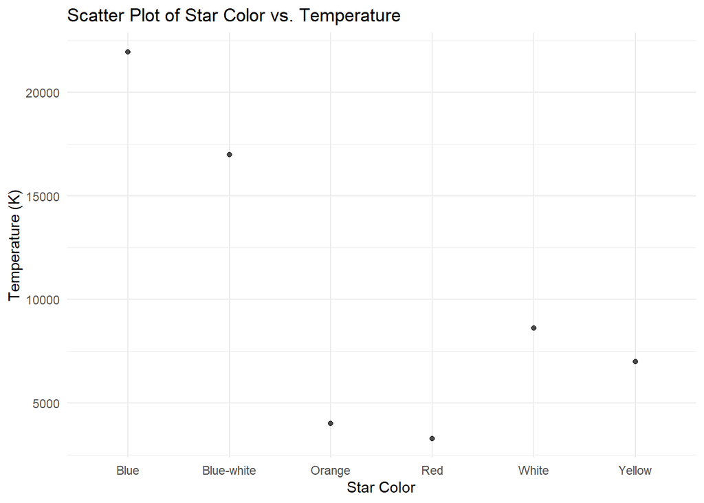

```r
# temperature over color
ggplot(means, aes(x = Color, y = `Temperature(K)`), color = Color) +
  geom_point(alpha = 0.7) +
  labs(title = "Scatter Plot of Star Color vs. Temperature",
       x = "Star Color",
       y = "Temperature (K)") +
  theme_minimal()
```

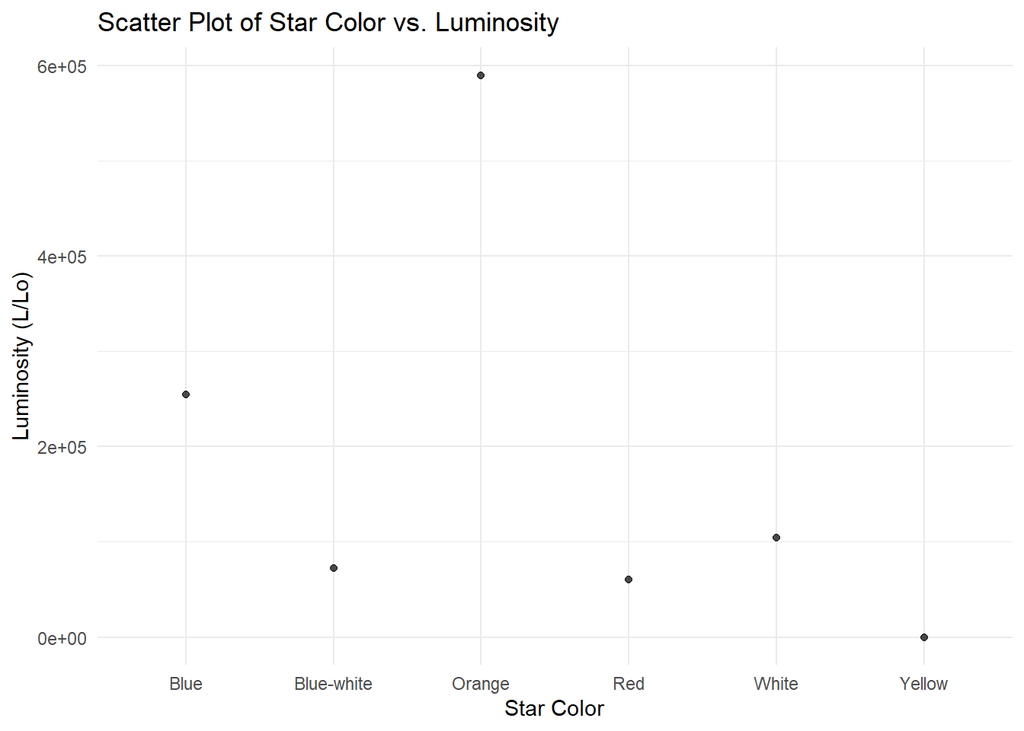

```r
# luminosity over color
ggplot(means, aes(x = Color, y = `Luminosity(L/Lo)`), color = Color) +
  geom_point(alpha = 0.7) +
  labs(title = "Scatter Plot of Star Color vs. Luminosity",
       x = "Star Color",
       y = "Luminosity (L/Lo)") +
  theme_minimal()
```

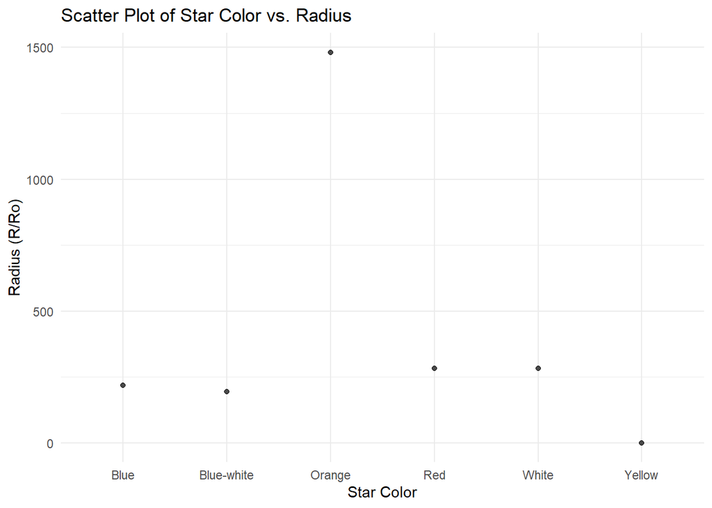

```r
# radius over color
ggplot(means, aes(x = Color, y = `Radius(R/Ro)`), color = Color) +
  geom_point(alpha = 0.7) +
  labs(title = "Scatter Plot of Star Color vs. Radius",
       x = "Star Color",
       y = "Radius (R/Ro)") +
  theme_minimal()
```

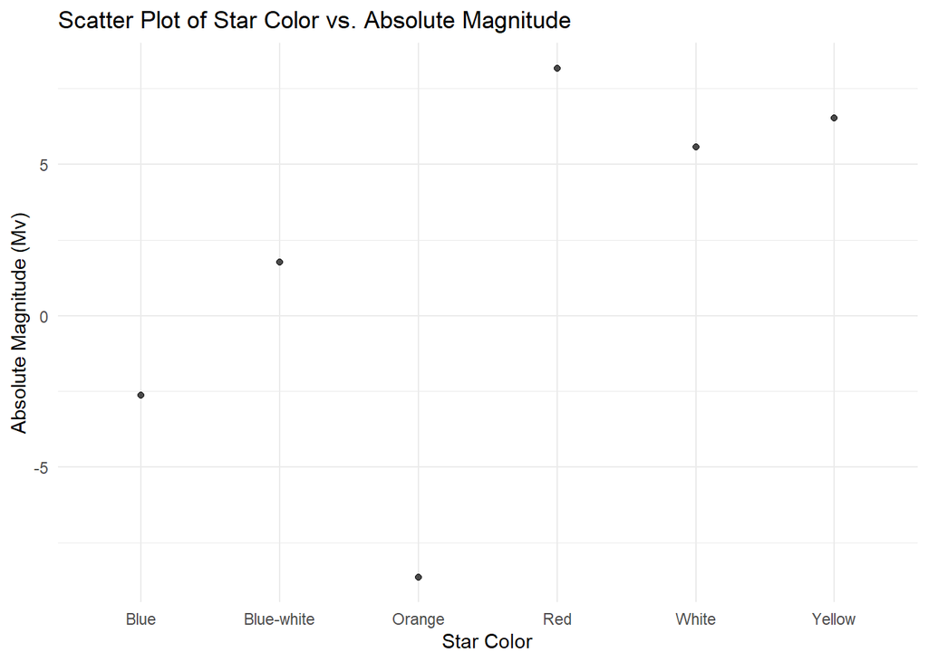

```r
# absolute magnitude over color
ggplot(means, aes(x = Color, y = `Absolute Magnitude(Mv)`), color = Color) +
  geom_point(alpha = 0.7) +
  labs(title = "Scatter Plot of Star Color vs. Absolute Magnitude",
       x = "Star Color",
       y = "Absolute Magnitude (Mv)") +
  theme_minimal()
```

#### Create pairs dataset for pairs plot.

```r
# pairs
pairs_data <- means
  pairs_data$Color <- as.factor(pairs_data$Color)
  levels(pairs_data$Color) <-
  c("White", "Red", "Blue4", "Blue", "Orange", "Yellow3")
pairs_data
```

```
## # A tibble: 6 × 5
##   Color   `Temperature(K)` `Luminosity(L/Lo)` `Radius(R/Ro)`
##   <fct>              <dbl>              <dbl>          <dbl>
## 1 Orange             8619.          104724.          282.
## 2 Blue               3292.           60527.          284.
## 3 White             21956.          254520.          219.
## 4 Red               16980.           72437.          195.
## 5 Blue4              4018           590000          1482.
## 6 Yellow3            6993.               1.61          0.807
## # ℹ 1 more variable: `Absolute Magnitude(Mv)` <dbl>
```

```r
custom <- c("Blue4" = "blue4", "Blue" = "blue",
             "Orange" = "orange", "Red" = "red",
             "White" = "white", "Yellow3" = "yellow3")
```

#### Plot pairs.

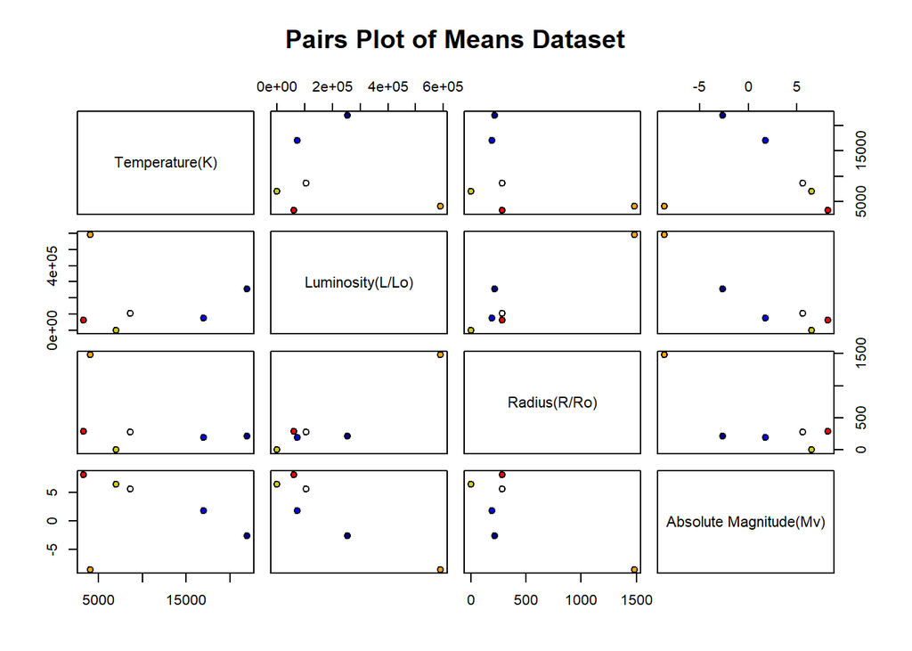

```r
pairs(pairs_data[, 2:5],
      main = "Pairs Plot of Means Dataset",
      pch = 21,
      bg = custom[pairs_data$Color])
```

#### Even more plots!!

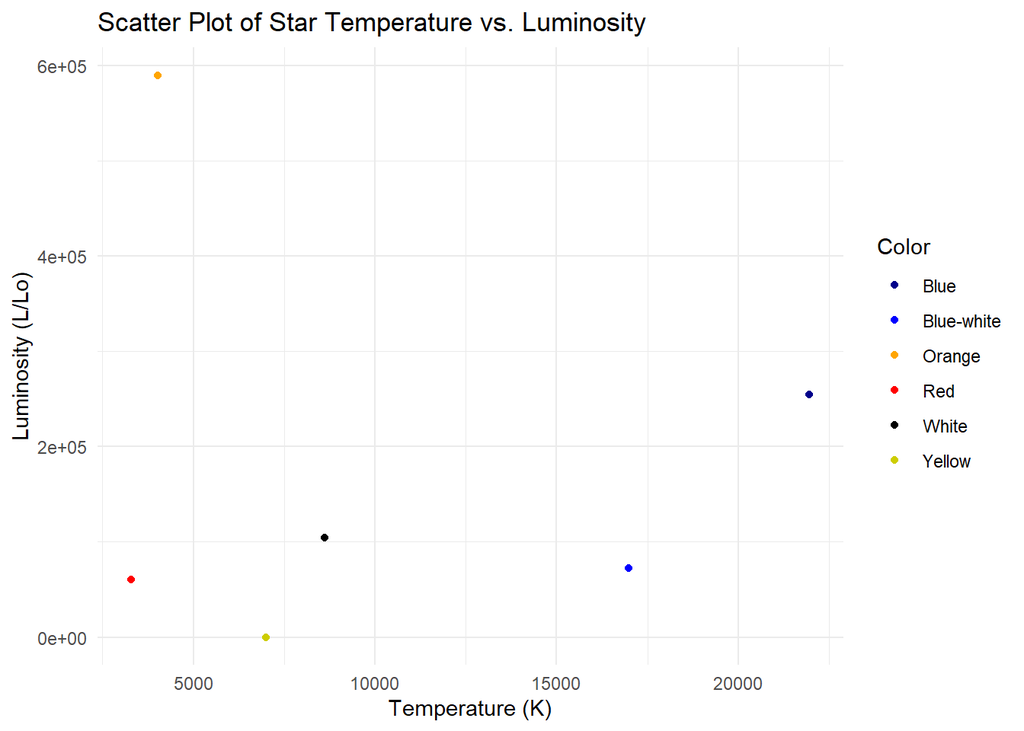

```r
# temperature vs. luminosity over color
ggplot(means, aes(`Temperature(K)`, `Luminosity(L/Lo)`, color = Color)) +
  geom_point() +
  scale_color_manual(values = c("Blue" = "blue4", "Blue-white" = "blue",
                                "Orange" = "orange", "Red" = "red",
                                "White" = "black", "Yellow" = "yellow3")) +
  labs(title = "Scatter Plot of Star Temperature vs. Luminosity",
       x = "Temperature (K)",
       y = "Luminosity (L/Lo)") +
  theme_minimal()
```

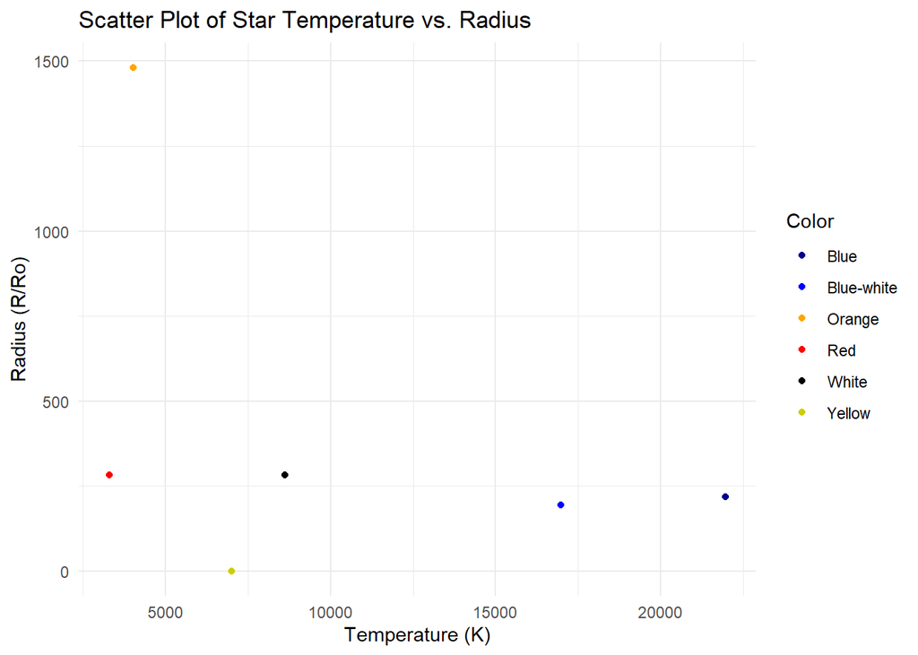

```r
# temperature vs. radius over color
ggplot(means, aes(`Temperature(K)`, `Radius(R/Ro)`, color = Color)) +
  geom_point() +
  scale_color_manual(values = c("Blue" = "blue4", "Blue-white" = "blue",
                                "Orange" = "orange", "Red" = "red",
                                "White" = "black", "Yellow" = "yellow3")) +
  labs(title = "Scatter Plot of Star Temperature vs. Radius",
       x = "Temperature (K)",
       y = "Radius (R/Ro)") +
  theme_minimal()
```